# Analyse des Disparités de Pauvreté en Tunisie

Comparaison Enquête Nationale vs Recensement Général (2023)

Mazzez Mohamed Amine

2025-12-28

# 1 Introduction

## 1.1 Contexte

Ce rapport présente une analyse statistique et géographique approfondie des **taux de pauvreté en Tunisie** au niveau des **24 gouvernorats**. L’objectif principal est de comparer deux sources de données majeures :

### 1.1.1 📊 Données Comparées

1. **L’Enquête Nationale sur le Budget, la Consommation et le Niveau de Vie** (méthode par échantillon)
2. **Le Recensement Général de la Population et de l’Habitat** (méthode exhaustive)

## 1.2 Objectifs

- ✓ Évaluer la **cohérence statistique** entre les deux mesures
- ✓ Identifier les **gouvernorats où les écarts sont significatifs**
- ✓ Cartographier les **disparités spatiales de la pauvreté**
- ✓ Analyser les **5 Districts administratifs**
- ✓ Tester l’existence d’un **biais systématique** entre les sources

# 2 Préparation de l’Environnement

```r
# Nettoyage de la session
rm(list = ls())
graphics.off()

# Chargement des packages
library(tidyverse)  # Manipulation de données et visualisation
library(sf)         # Données spatiales
library(tmap)       # Cartographie thématique
library(broom)      # Export des résultats de régression

# Désactiver s2 pour éviter les erreurs géométriques
sf::sf_use_s2(FALSE)
```

```
## Spherical geometry (s2) switched off
```

# 3 Import et Nettoyage des Données

## 3.1 Import des données brutes

```r
# Import du fichier CSV
raw_pauv <- read.csv2("pauvrete.csv",
                      sep = ";",
                      dec = ".",
                      header = FALSE,
                      stringsAsFactors = FALSE)

# Aperçu
head(raw_pauv, 10)
```

```
##               V1            V2         V3                             V4
## 1  Gouvernorat\n       enquete
## 2                Taux_pauvrete Ecart_type Intervalle de confidence\n95 %
## 3                                                             Niveau bas
## 4          TUNIS           3.5     0.5748                            2.4
## 5         ARIANA           5.4     0.6976                            4.0
## 6      BEN AROUS           4.3     0.5946                            3.1
## 7        MANOUBA          12.1     1.3788                            9.4
## 8         NABEUL           7.4     0.8000                            5.8
## 9       ZAGHOUAN          12.1     1.3110                            9.6
## 10       BIZERTE          17.5     1.1201                           15.3
##              V5            V6         V7                 V8
## 1                 recensement
## 2               Taux_pauvrete Ecart_type Difference_absolue
## 3  Niveau élevé
## 4           4.6           4.6     0.3601                1.1
## 5           6.8           7.0     1.0237                1.6
## 6           5.4           5.6     0.2877                1.4
## 7          14.8           9.8     0.6971                2.3
## 8           9.0           8.1     0.5165                0.7
## 9          14.7          13.7     0.6048                1.6
## 10         19.7          16.9     0.5354                0.5
```

```r
dim(raw_pauv)
```

```
## [1] 27  8
```

## 3.2 Construction du DataFrame propre

```r
# Suppression des 3 premières lignes (en-têtes complexes)
pauv <- raw_pauv[-c(1:3), ]

# Renommage des colonnes
colnames(pauv) <- c("Gouvernorat",
                    "Taux_enquete", "Ecart_type_enquete", "IC95_bas", "IC95_haut",
                    "Taux_recensement", "Ecart_type_recensement", "Diff_absolue")

# Conversion des types
pauv <- pauv %>%
  mutate(
    Gouvernorat = factor(Gouvernorat),
    across(Taux_enquete:Diff_absolue, as.numeric),
    Gouv_clean = toupper(as.character(Gouvernorat))
  ) %>%
  mutate(Gouv_clean = ifelse(str_detect(Gouv_clean, "KEF"), "LE KEF", Gouv_clean))

# Vérification
str(pauv)
```

```
## 'data.frame':    24 obs. of  9 variables:
##  $ Gouvernorat           : Factor w/ 24 levels "ARIANA","BEJA",..: 23 1 3 13 16 24 4 2 7 11 ...
##  $ Taux_enquete          : num  3.5 5.4 4.3 12.1 7.4 12.1 17.5 32 22.4 34.2 ...
##  $ Ecart_type_enquete    : num  0.575 0.698 0.595 1.379 0.8 ...
##  $ IC95_bas              : num  2.4 4 3.1 9.4 5.8 9.6 15.3 28.4 20 31.4 ...
##  $ IC95_haut             : num  4.6 6.8 5.4 14.8 9 14.7 19.7 35.6 24.8 37.1 ...
##  $ Taux_recensement      : num  4.6 7 5.6 9.8 8.1 13.7 16.9 26.4 21.5 33.1 ...
##  $ Ecart_type_recensement: num  0.36 1.024 0.288 0.697 0.516 ...
##  $ Diff_absolue          : num  1.1 1.6 1.4 2.3 0.7 1.6 0.5 5.6 0.9 1.1 ...
##  $ Gouv_clean            : chr  "TUNIS" "ARIANA" "BEN AROUS" "MANOUBA" ...
```

```r
summary(pauv)
```

```
##     Gouvernorat  Taux_enquete   Ecart_type_enquete    IC95_bas
##  ARIANA   : 1   Min.   : 3.50   Min.   :0.5610     Min.   : 2.400
##  BEJA     : 1   1st Qu.:11.15   1st Qu.:0.9921     1st Qu.: 8.575
##  BEN AROUS: 1   Median :16.85   Median :1.1346     Median :14.650
##  BIZERTE  : 1   Mean   :17.68   Mean   :1.1435     Mean   :15.425
##  GABES    : 1   3rd Qu.:22.57   3rd Qu.:1.3158     3rd Qu.:20.200
##  GAFSA    : 1   Max.   :34.90   Max.   :1.8484     Max.   :32.200
##  (Other)  :18
##    IC95_haut     Taux_recensement Ecart_type_recensement  Diff_absolue
##  Min.   : 4.60   Min.   : 4.600   Min.   :0.2877         Min.   :0.000
##  1st Qu.:13.68   1st Qu.: 9.375   1st Qu.:0.4191         1st Qu.:0.775
##  Median :19.00   Median :17.350   Median :0.6561         Median :1.250
##  Mean   :19.93   Mean   :17.442   Mean   :0.6395         Mean   :1.817
##  3rd Qu.:24.95   3rd Qu.:24.775   3rd Qu.:0.8222         3rd Qu.:2.425
##  Max.   :37.50   Max.   :33.600   Max.   :1.1083         Max.   :5.600
##
##   Gouv_clean
##  Length:24
##  Class :character
##  Mode  :character
##
##
##
##
```

# 4 Création des Variables Dérivées

```r
pauv <- pauv %>%
  mutate(
    # Largeur de l'intervalle de confiance
    Largeur_IC = IC95_haut - IC95_bas,

    # Différence absolue et relative
    Diff = Taux_recensement - Taux_enquete,
    Diff_relatif = Diff / Taux_recensement,

    # Cohérence : recensement dans l'IC de l'enquête ?
    Recensement_dans_IC = (Taux_recensement >= IC95_bas) & (Taux_recensement <= IC95_haut)
  )

# Résumé de la cohérence
table(pauv$Recensement_dans_IC)
```

```
##
## FALSE  TRUE
##     7    17
```

**Résultat** : 17 gouvernorats sur 24 ont un taux de recensement cohérent avec l’intervalle de confiance de l’enquête.

# 5 Statistiques Descriptives

## 5.1 Résumé global

```r
summary_select <- pauv %>%
  select(Taux_enquete, Taux_recensement, Diff, Diff_relatif, Largeur_IC)

summary(summary_select)
```

```
##   Taux_enquete   Taux_recensement      Diff          Diff_relatif
##  Min.   : 3.50   Min.   : 4.600   Min.   :-5.6000   Min.   :-0.23469
##  1st Qu.:11.15   1st Qu.: 9.375   1st Qu.:-1.3000   1st Qu.:-0.08881
##  Median :16.85   Median :17.350   Median : 0.6000   Median : 0.03013
##  Mean   :17.68   Mean   :17.442   Mean   :-0.2375   Mean   : 0.01256
##  3rd Qu.:22.57   3rd Qu.:24.775   3rd Qu.: 1.1500   3rd Qu.: 0.09401
##  Max.   :34.90   Max.   :33.600   Max.   : 3.9000   Max.   : 0.23913
##    Largeur_IC
##  Min.   :2.200
##  1st Qu.:3.900
##  Median :4.450
##  Mean   :4.508
##  3rd Qu.:5.225
##  Max.   :7.200
```

```r
# Statistiques détaillées
desc_stats <- summary_select %>%
  summarise(
    across(
      everything(),
      list(
        mean = ~ mean(., na.rm = TRUE),
        median = ~ median(., na.rm = TRUE),
        sd = ~ sd(., na.rm = TRUE),
        min = ~ min(., na.rm = TRUE),
        max = ~ max(., na.rm = TRUE)
      ),
      .names = "{.col}_{.fn}"
    )
  )

knitr::kable(desc_stats, digits = 2, caption = "Statistiques descriptives détaillées")
```

Statistiques descriptives détaillées

| Taux_enquete_mean | Taux_enquete_median | Taux_enquete_sd | Taux_enquete_min | Taux_enquete_max | Taux_recensement_mean | Taux_recensement_median | Taux_recensement_sd | Taux_recensement_min | Taux_recensement_max | Diff_mean | Diff_median | Diff_sd | Diff_min | Diff_max | Diff_relatif_mean | Diff_relatif_median | Diff_relatif_sd | Diff_relatif_min | Diff_relatif_max | Largeur_IC_mean | Largeur_IC_median | Largeur_IC_sd | Largeur_IC_min | Largeur_IC_max |
| --- | --- | --- | --- | --- | --- | --- | --- | --- | --- | --- | --- | --- | --- | --- | --- | --- | --- | --- | --- | --- | --- | --- | --- | --- |
| 17.68 | 16.85 | 9.63 | 3.5 | 34.9 | 17.44 | 17.35 | 8.67 | 4.6 | 33.6 | -0.24 | 0.6 | 2.38 | -5.6 | 3.9 | 0.01 | 0.03 | 0.14 | -0.23 | 0.24 | 4.51 | 4.45 | 1.34 | 2.2 | 7.2 |

## 5.2 Comparaison visuelle : Boxplots

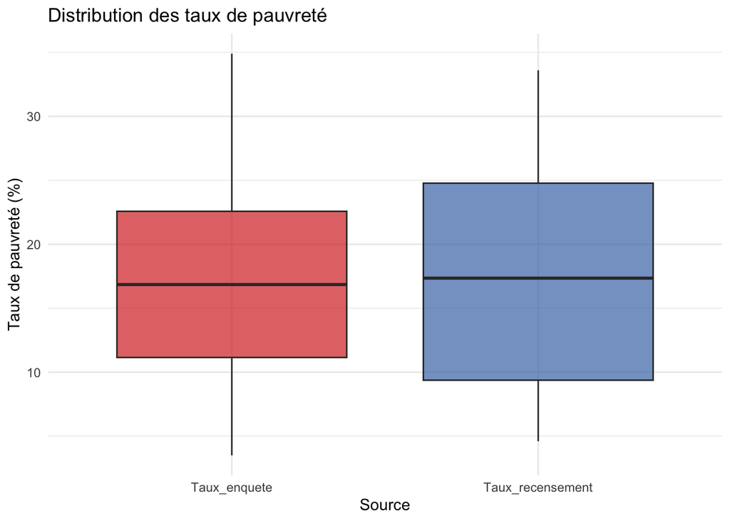

```r
pauv_long_taux <- pauv %>%
  select(Gouvernorat, Taux_enquete, Taux_recensement) %>%
  pivot_longer(cols = c(Taux_enquete, Taux_recensement),
               names_to = "Source",
               values_to = "Taux")

ggplot(pauv_long_taux, aes(x = Source, y = Taux, fill = Source)) +
  geom_boxplot(alpha = 0.7) +
  scale_fill_manual(values = c("#D73027", "#4575B4")) +
  labs(title = "Distribution des taux de pauvreté",
       x = "Source", y = "Taux de pauvreté (%)") +
  theme_minimal() +
  theme(legend.position = "none")
```

# 6 Visualisations Comparatives

## 6.1 Barplot : Enquête vs Recensement

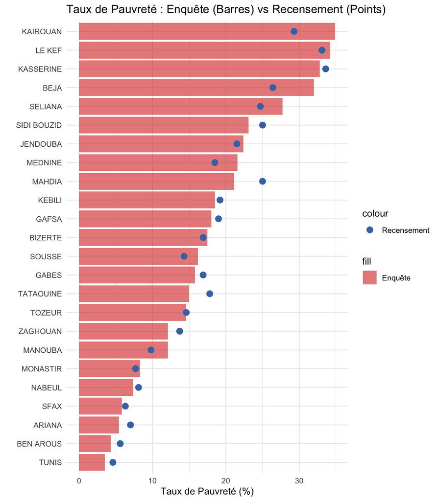

```r
pauv <- pauv %>%
  mutate(Gouvernorat = fct_reorder(Gouvernorat, Taux_enquete))

ggplot(pauv, aes(x = Gouvernorat)) +
  geom_col(aes(y = Taux_enquete, fill = "Enquête"), alpha = 0.6) +
  geom_point(aes(y = Taux_recensement, color = "Recensement"), size = 3) +
  coord_flip() +
  scale_fill_manual(values = "#D73027") +
  scale_color_manual(values = "#4575B4") +
  labs(title = "Taux de Pauvreté : Enquête (Barres) vs Recensement (Points)",
       x = "", y = "Taux de Pauvreté (%)") +
  theme_minimal()
```

## 6.2 Nuage de points : Corrélation

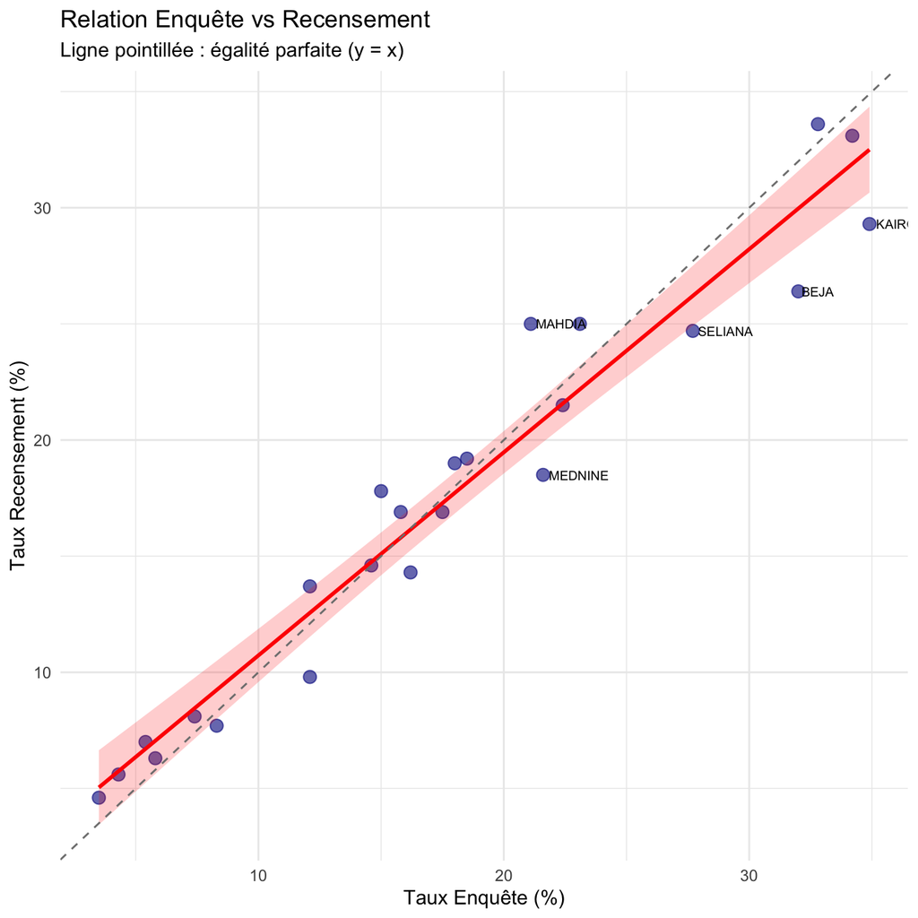

```r
ggplot(pauv, aes(x = Taux_enquete, y = Taux_recensement)) +
  geom_point(color = "darkblue", size = 3, alpha = 0.6) +
  geom_smooth(method = "lm", color = "red", fill = "red", alpha = 0.2) +
  geom_abline(intercept = 0, slope = 1, linetype = "dashed", color = "gray50") +
  geom_text(aes(label = Gouvernorat), hjust = -0.1, vjust = 0.5, size = 2.5,
            data = pauv %>% slice_max(abs(Diff), n = 5)) +
  labs(title = "Relation Enquête vs Recensement",
       subtitle = "Ligne pointillée : égalité parfaite (y = x)",
       x = "Taux Enquête (%)", y = "Taux Recensement (%)") +
  theme_minimal()
```

# 7 Analyse de la Cohérence Statistique

## 7.1 Test des Intervalles de Confiance

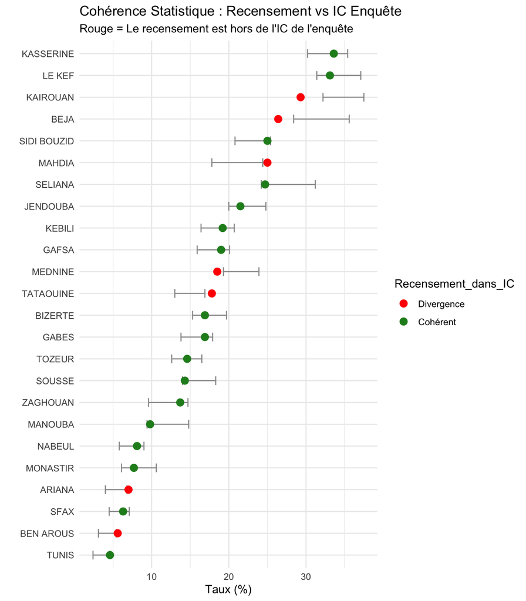

```r
ggplot(pauv, aes(x = reorder(Gouvernorat, Taux_recensement), y = Taux_recensement)) +
  geom_errorbar(aes(ymin = IC95_bas, ymax = IC95_haut), width = 0.4, color = "gray60") +
  geom_point(aes(color = Recensement_dans_IC), size = 3) +
  coord_flip() +
  scale_color_manual(values = c("FALSE" = "red", "TRUE" = "forestgreen"),
                     labels = c("Divergence", "Cohérent")) +
  labs(title = "Cohérence Statistique : Recensement vs IC Enquête",
       subtitle = "Rouge = Le recensement est hors de l'IC de l'enquête",
       x = "", y = "Taux (%)") +
  theme_minimal()
```

**Gouvernorats en divergence** (hors IC) :

```r
pauv %>%
  filter(!Recensement_dans_IC) %>%
  select(Gouvernorat, Taux_enquete, Taux_recensement, Diff) %>%
  arrange(desc(abs(Diff))) %>%
  knitr::kable(digits = 2)
```

| Gouvernorat | Taux_enquete | Taux_recensement | Diff |
| --- | --- | --- | --- |
| BEJA | 32.0 | 26.4 | -5.6 |
| KAIROUAN | 34.9 | 29.3 | -5.6 |
| MAHDIA | 21.1 | 25.0 | 3.9 |
| MEDNINE | 21.6 | 18.5 | -3.1 |
| TATAOUINE | 15.0 | 17.8 | 2.8 |
| ARIANA | 5.4 | 7.0 | 1.6 |
| BEN AROUS | 4.3 | 5.6 | 1.3 |

# 8 Modèle de Régression Linéaire

## 8.1 Ajustement du modèle

```r
modele_lin <- lm(Taux_recensement ~ Taux_enquete, data = pauv)
summary(modele_lin)
```

```
##
## Call:
## lm(formula = Taux_recensement ~ Taux_enquete, data = pauv)
##
## Residuals:
##     Min      1Q  Median      3Q     Max
## -3.5667 -1.5141 -0.1444  1.1557  4.5665
##
## Coefficients:
##              Estimate Std. Error t value Pr(>|t|)
## (Intercept)   1.97947    0.91005   2.175   0.0406 *
## Taux_enquete  0.87460    0.04542  19.256 2.94e-15 ***
## ---
## Signif. codes:  0 '***' 0.001 '**' 0.01 '*' 0.05 '.' 0.1 ' ' 1
##
## Residual standard error: 2.098 on 22 degrees of freedom
## Multiple R-squared:  0.944,  Adjusted R-squared:  0.9414
## F-statistic: 370.8 on 1 and 22 DF,  p-value: 2.94e-15
```

```r
# Extraction des paramètres
cor_pearson <- cor(pauv$Taux_enquete, pauv$Taux_recensement)
r_squared <- summary(modele_lin)$r.squared
```

**Équation du modèle** :
$$\text{Taux Recensement} = 1.98 + 0.87 \times \text{Taux Enquête}$$

**Interprétation** :

- **Corrélation de Pearson** : 0.972 → Très forte corrélation
- **R²** : 0.944 → Le modèle explique 94.4% de la variance

## 8.2 Visualisation avec droite de régression

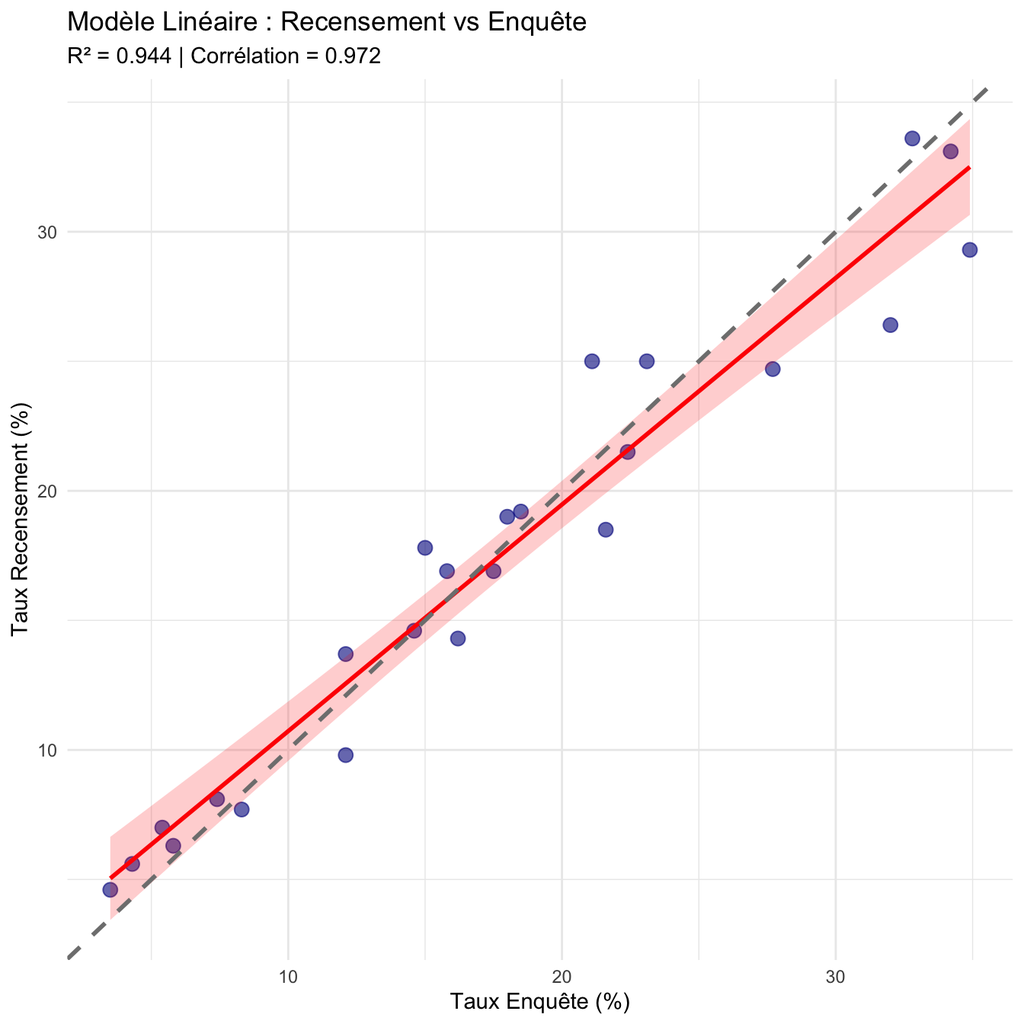

```r
ggplot(pauv, aes(x = Taux_enquete, y = Taux_recensement)) +
  geom_point(color = "darkblue", size = 3, alpha = 0.6) +
  geom_smooth(method = "lm", color = "red", fill = "red", alpha = 0.2, formula = y ~ x) +
  geom_abline(intercept = 0, slope = 1, linetype = "dashed", color = "gray50", linewidth = 1) +
  labs(title = "Modèle Linéaire : Recensement vs Enquête",
       subtitle = paste("R² =", round(r_squared, 3), "| Corrélation =", round(cor_pearson, 3)),
       x = "Taux Enquête (%)", y = "Taux Recensement (%)") +
  theme_minimal()
```

# 9 Test de la Différence Moyenne (Test t Apparié)

```r
test_t <- t.test(pauv$Taux_recensement, pauv$Taux_enquete, paired = TRUE, conf.level = 0.95)
test_t
```

```
##
##  Paired t-test
##
## data:  pauv$Taux_recensement and pauv$Taux_enquete
## t = -0.48869, df = 23, p-value = 0.6297
## alternative hypothesis: true mean difference is not equal to 0
## 95 percent confidence interval:
##  -1.2428524  0.7678524
## sample estimates:
## mean difference
##         -0.2375
```

```r
# Extraction des résultats
mean_diff <- test_t$estimate
p_value_t <- test_t$p.value
```

**Résultats** :

- **Différence moyenne** : -0.24 points de pourcentage
- **p-value** : 0.63

**Interprétation** :

✓ **Résultat NON SIGNIFICATIF** (p ≥ 0.05) :

La différence observée n’est **pas statistiquement différente de 0**.

Les deux méthodes ne présentent **pas de biais systématique** l’une par rapport à l’autre.

## 9.1 Distribution des différences

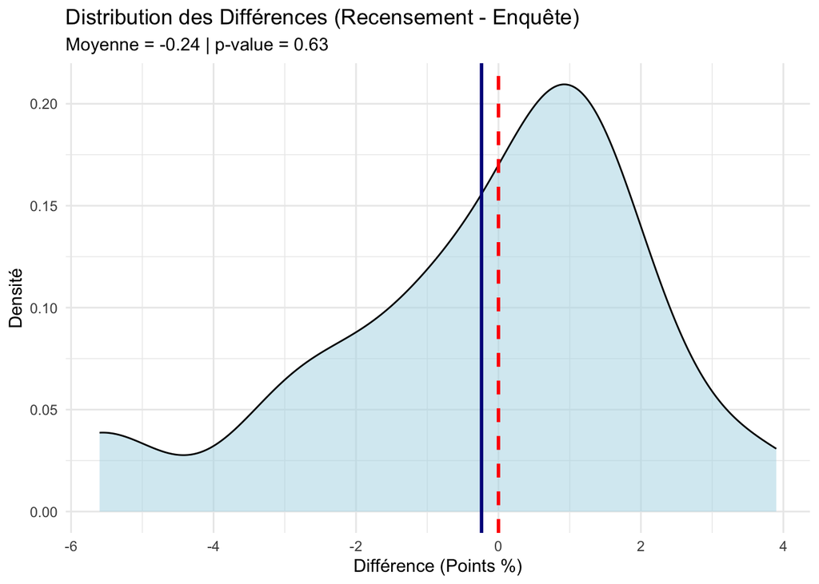

```r
ggplot(pauv, aes(x = Diff)) +
  geom_density(fill = "lightblue", alpha = 0.5) +
  geom_vline(xintercept = 0, linetype = "dashed", color = "red", linewidth = 1) +
  geom_vline(xintercept = mean_diff, color = "darkblue", linewidth = 1) +
  labs(title = "Distribution des Différences (Recensement - Enquête)",
       subtitle = paste("Moyenne =", round(mean_diff, 2), "| p-value =", format.pval(p_value_t, digits = 3)),
       x = "Différence (Points %)", y = "Densité") +
  theme_minimal()
```

# 10 Cartographie des Disparités

## 10.1 Import et préparation des données spatiales

```r
# Import du GeoJSON
gouv_sf <- st_read("decoupage.geojson.json", quiet = TRUE)

# Harmonisation des noms
gouv_sf <- gouv_sf %>%
  mutate(Gouv_clean = toupper(gov_name_f)) %>%
  mutate(Gouv_clean = case_when(
    Gouv_clean == "SILIANA"       ~ "SELIANA",
    Gouv_clean == "KEF"           ~ "LE KEF",
    Gouv_clean == "MANUBAH"       ~ "MANOUBA",
    Gouv_clean == "BÉJA"          ~ "BEJA",
    Gouv_clean == "JENDOUBA"      ~ "JENDOUBA",
    Gouv_clean == "KASSÉRINE"     ~ "KASSERINE",
    Gouv_clean == "SIDI BOU ZID"  ~ "SIDI BOUZID",
    Gouv_clean == "GABÈS"         ~ "GABES",
    Gouv_clean == "MÉDENINE"      ~ "MEDNINE",
    Gouv_clean == "TATAOUINE"     ~ "TATAOUINE",
    TRUE ~ Gouv_clean
  ))

# Jointure avec les données de pauvreté
carte_pauv <- gouv_sf %>% left_join(pauv, by = "Gouv_clean")

# Définition des 5 districts
districts_5 <- data.frame(
  Gouvernorat = c("BIZERTE", "BEJA", "JENDOUBA", "LE KEF",
                  "TUNIS", "ARIANA", "BEN AROUS", "MANOUBA", "ZAGHOUAN", "NABEUL",
                  "SELIANA", "SOUSSE", "KASSERINE", "KAIROUAN", "MONASTIR", "MAHDIA",
                  "TOZEUR", "SIDI BOUZID", "SFAX", "GAFSA",
                  "TATAOUINE", "GABES", "MEDNINE", "KEBILI"),
  District = c(rep("D1: Nord-Ouest", 4), rep("D2: Nord-Est/Tunis", 6),
               rep("D3: Centre", 6), rep("D4: Sud-Ouest/Centre-Est", 4),
               rep("D5: Sud-Est", 4))
)
districts_5$Gouv_clean <- toupper(districts_5$Gouvernorat)

# Création de la géométrie des districts
sf_districts <- gouv_sf %>%
  left_join(districts_5, by = "Gouv_clean") %>%
  st_make_valid() %>%
  group_by(District) %>%
  summarise(geometry = st_union(geometry)) %>%
  left_join(
    pauv %>% left_join(districts_5, by = "Gouv_clean") %>%
      group_by(District) %>%
      summarise(
        Moyenne_Enquete = mean(Taux_enquete, na.rm = TRUE),
        Moyenne_Recensement = mean(Taux_recensement, na.rm = TRUE),
        .groups = "drop"
      ),
    by = "District"
  )
```

[output not shown]

## 10.2 Cartes choroplèthes : Enquête et Recensement

```r
# Activation du mode tmap
tmap_mode("plot")
```

```
## ℹ tmap modes "plot" - "view"
## ℹ toggle with `tmap::ttm()`
```

```r
# Carte 1 : Enquête
m1 <- tm_shape(carte_pauv) +
  tm_polygons("Taux_enquete", palette = "Reds", title = "Taux_enquete (%)",
              breaks = seq(0, 35, by = 5)) +
  tm_layout(title = "Pauvreté (Enquête)", frame = TRUE)
```

[output not shown]

```r
# Carte 2 : Recensement
m2 <- tm_shape(carte_pauv) +
  tm_polygons("Taux_recensement", palette = "Blues", title = "Taux_recensement (%)",
              breaks = seq(0, 35, by = 5)) +
  tm_layout(title = "Pauvreté (Recensement)", frame = TRUE)
```

```
## [v3->v4] `tm_polygons()`: migrate the argument(s) related to the legend of the
## visual variable `fill` namely 'title' to 'fill.legend = tm_legend(<HERE>)'
## [v3->v4] `tm_layout()`: use `tm_title()` instead of `tm_layout(title = )`
```

```r
# Affichage côte à côte
tmap_arrange(m1, m2)
```

[output not shown]

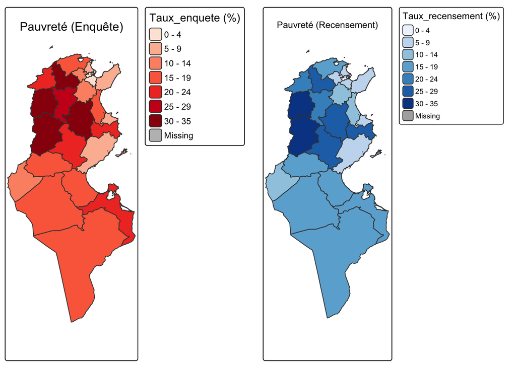

**Figure** : Répartition géographique des taux de pauvreté. À gauche : données de l’Enquête. À droite : données du Recensement.

## 10.3 Carte des divergences

```r
# Créer une variable pour les divergences avec seuil statistique
carte_pauv <- carte_pauv %>%
  mutate(
    Coherence = Recensement_dans_IC,
    Diff_cat = case_when(
      Diff > 5 ~ "Écart > 5pts",
      Diff >= 0 ~ "0 ≤ Écart ≤ 5pts",
      Diff >= -5 ~ "-5pts ≤ Écart < 0",
      TRUE ~ "Écart < -5pts"
    )
  )

# Carte des différences
tm_shape(carte_pauv) +
  tm_polygons("Diff", palette = "RdYlBu", title = "Différence (pts %)",
              midpoint = 0, breaks = seq(-6, 6, by = 2)) +
  tm_layout(title = "Écart Recensement - Enquête", frame = TRUE)
```

```
## ── tmap v3 code detected ───────────────────────────────────────────────────────
```

[output not shown]

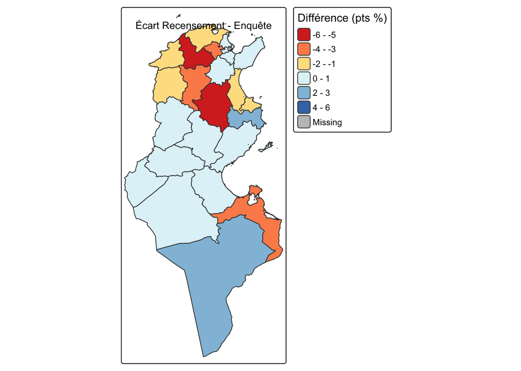

## 10.4 Carte de cohérence statistique

```r
# Créer une palette pour cohérence
carte_pauv <- carte_pauv %>%
  mutate(Coherence_char = ifelse(Coherence, "Cohérent", "Divergence"))

tm_shape(carte_pauv) +
  tm_polygons("Coherence_char", palette = c("Cohérent" = "forestgreen", "Divergence" = "red"),
              title = "Cohérence") +
  tm_text("Gouv_clean", size = 0.5, fontface = "bold") +
  tm_layout(title = "Validité Statistique", frame = TRUE)
```

```
## ── tmap v3 code detected ───────────────────────────────────────────────────────
```

[output not shown]

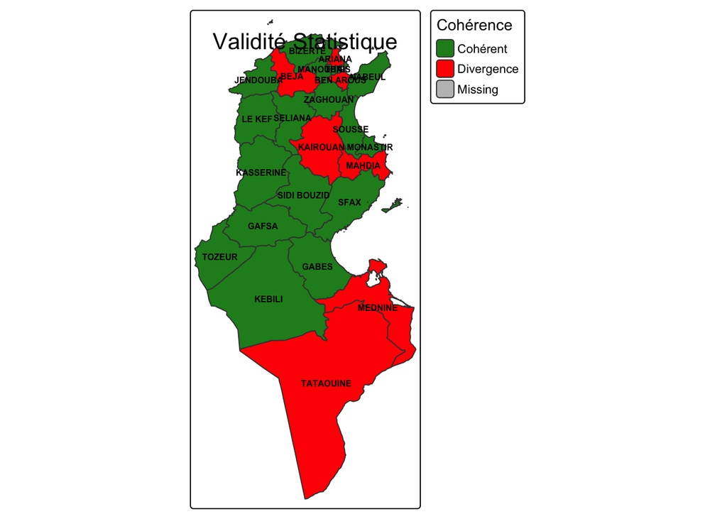

**Figure** : Validité statistique. En vert : le taux du Recensement est cohérent avec l’intervalle de confiance de l’Enquête. En rouge : divergence significative.

# 11 Analyse par Districts (5 Régions)

## 11.1 Tableau des districts

```r
pauv_dist_data <- pauv %>%
  left_join(districts_5, by = "Gouv_clean") %>%
  group_by(District) %>%
  summarise(
    Moyenne_Enquete = mean(Taux_enquete, na.rm = TRUE),
    Moyenne_Recensement = mean(Taux_recensement, na.rm = TRUE),
    .groups = "drop"
  )

knitr::kable(pauv_dist_data, digits = 2, caption = "Taux moyens de pauvreté par District")
```

Taux moyens de pauvreté par District

| District | Moyenne_Enquete | Moyenne_Recensement |
| --- | --- | --- |
| D1: Nord-Ouest | 26.52 | 24.48 |
| D2: Nord-Est/Tunis | 7.47 | 8.13 |
| D3: Centre | 23.50 | 22.43 |
| D4: Sud-Ouest/Centre-Est | 15.38 | 16.23 |
| D5: Sud-Est | 17.73 | 18.10 |

## 11.2 Cartes des Districts

```r
# Carte 1 : Districts Enquête
d1 <- tm_shape(sf_districts) +
  tm_polygons("Moyenne_Enquete", palette = "Reds", title = "Taux moyen (%)",
              breaks = seq(5, 30, by = 5)) +
  tm_text("District", size = 0.6, fontface = "bold") +
  tm_layout(title = "Pauvreté par District (Enquête)", frame = TRUE)
```

```
## ── tmap v3 code detected ───────────────────────────────────────────────────────
```

[output not shown]

```r
# Carte 2 : Districts Recensement
d2 <- tm_shape(sf_districts) +
  tm_polygons("Moyenne_Recensement", palette = "Blues", title = "Taux moyen (%)",
              breaks = seq(5, 30, by = 5)) +
  tm_text("District", size = 0.6, fontface = "bold") +
  tm_layout(title = "Pauvreté par District (Recensement)", frame = TRUE)
```

```
## [v3->v4] `tm_polygons()`: migrate the argument(s) related to the legend of the
## visual variable `fill` namely 'title' to 'fill.legend = tm_legend(<HERE>)'
## [v3->v4] `tm_layout()`: use `tm_title()` instead of `tm_layout(title = )`
```

```r
# Affichage côte à côte
tmap_arrange(d1, d2)
```

[output not shown]

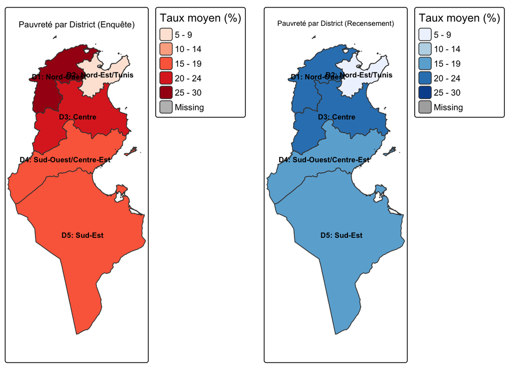

**Figure** : Taux moyens de pauvreté par District. À gauche : Enquête. À droite : Recensement. Le découpage en 5 Districts révèle des disparités régionales marquées : le Nord-Ouest (D1) et le Centre (D3) sont les plus pauvres, tandis que le Nord-Est/Tunis (D2) est le moins touché.

# 12 Aperçu générale

## 12.1 Principaux résultats

1. **Corrélation forte** entre enquête et recensement (r = 0.972)
2. **7 gouvernorats** présentent des divergences significatives
3. **Pas de biais systématique** global (p = 0.63)
4. **Disparités régionales** : le Nord-Est/Tunis moins pauvre que l’intérieur (Centre, Nord-Ouest, Sud)

## 12.2 Recommandations

- Investiguer les gouvernorats en **divergence** (KAIROUAN, BEJA, MAHDIA, MEDNINE, TATAOUINE)
- Harmoniser les **méthodologies** de collecte de données
- Utiliser les **cartes** pour cibler les politiques sociales

Les résultats montrent que malgré quelques divergences locales, les deux méthodes convergent globalement, validant ainsi la robustesse des estimations de pauvreté en Tunisie.

# 13 Conclusion

Cette analyse comparative des taux de pauvreté en Tunisie au niveau des 24 gouvernorats a permis d’évaluer la cohérence entre l’Enquête Nationale (méthode par échantillonnage) et le Recensement Général (méthode exhaustive). Les résultats révèlent une forte convergence globale entre ces deux sources, avec une corrélation de Pearson de 0.972 et un coefficient de détermination R² élevé. Le test t apparié (p = 0.63) confirme l’absence de biais systématique significatif entre les deux méthodes.

Cependant, des divergences localisées persistent dans 7 gouvernorats où les taux du Recensement se situent hors des intervalles de confiance de l’Enquête, notamment à Kairouan, Béja, Mahdia, Médenine et Tataouine. L’analyse spatiale par districts met également en évidence des disparités régionales marquées : le Nord-Est (incluant Tunis) affiche les taux les plus faibles, tandis que le Nord-Ouest et le Centre présentent les niveaux de pauvreté les plus élevés.

Ces résultats suggèrent trois recommandations majeures : investiguer les causes des divergences observées dans certains gouvernorats, harmoniser les méthodologies de collecte entre les deux sources, et utiliser les cartographies produites pour cibler géographiquement les politiques sociales. En conclusion, cette étude valide la robustesse des estimations de pauvreté en Tunisie et fournit une base solide pour orienter les interventions visant à réduire les inégalités territoriales.

**Auteur** : Mazzez Mohamed Amine  
**Date** : 2025-12-28  
**Outils** : R 4.5.1, RStudio, tidyverse, sf, tmap